# A3: Data set Pathway and Network Analysis

Yining Ding

# Data source

- The GEO series used in this assignment is GSE84054, “Transcriptome profiling of ER+ breast cancer primary tumor and its tumorsphere derivative” (Goh et al. 2017). The data contains 12 patients, each having both tumursphere and primary tumour. From the paper, the authors performed RNA-seq analysis to find differentially expressed genes from the two groups. They also discovered a potential drug target. The drug they sugguested that may have effect is Pacritinib which is still being annotated.

# Objective of A3

The objective of this third assignment is to use the ranked file from A2 and perform non-thresholded analysis with GSEA (Version 4.0.3) (Efron and Tibshirani 2019). Then the result is compared to the result from thresholded analysis in A2. Finally, cytoscape (Version 3.7.2, Java 1.8.0_162 by Oracle Corporation)(Lopes et al. 2010) is used to help to create a visualization of the up and down regulated genes along with annotations from the Bader lab. Post analysis is performed with drugBank datasets from Bader lab as well. Other details such as performing the analysis of cytoscape can be retrieved from [my Journal](https://github.com/bcb420-2020/student_helen307/wiki/a3)

# A1 and A2

Work from A1 and A2 are embedded in this notebook. In A1, we performed data cleaning, normalization and general analysis with density and box plots. In A2, we explored the differentially expressed genes and ranked them with thresholded analysis to highlight the top terms. And also found some evidence that supported my work from some other papers. Other details from A1 and A2 can also be found in my journal.

# Introduction

The objective of this second assignment is to explore the differentially expressed genes from the cleaned and normalized data in assignmnent one. Then rank the thresholded over-representation analysis to highlight the top terms / dominant themes in the top set of genes. Lastly, compare my result with the original literature and find some other supports as well for my result if possible. I make some changes to my assignment one and stored the file as “ammended_A1.Rmd” and imported it here. I will demonstrate briefly what I have changed in general workflow in A1. My summary of the paper can be found at [my journal](https://github.com/bcb420-2020/student_helen307/wiki/a1) or in A1

(Ritchie et al. 2015) (Robinson, McCarthy, and Smyth 2010) (Rainer 2017) (Xie 2020) (Gu, Eils, and Schlesner 2016) (Gu et al. 2014) (Kolberg and Raudvere 2019)

# A1

My data is from GSE84054 (Goh et al. 2017)

What I have changed in A1: I decided to leave the genes that have duplicated names because Ruth sugguested that they are a very small number compare to my total number of genes, ~1%. So I deleted many steps in A1, and made the cleaning step clearer by showing boxplots, density plots and MDS plots in each cleaning step.

- Download data
- Group samples - pre-filtered
- Check GENEID duplications
- Explore
1. Boxplot - prefiltered
2. Density Plot - prefiltered
3. MDS plot - prefiltered
- Filter
- Explore: filtered
1. Boxplot - filtered
2. Density plot - filtered
3. MDS plot - filtered
- Identifier mapping
- Unmapped GENEIDs
- I proved in A1 that the 17 unmapped gene ids are actually duplicates. The reason why the previous check did not catch them was because if we change the “R” to “0”, they can be detected. (They are exactly same, except locating on the Y chromosome). So here I am just going to remove them.
- Group samples - Filtered (SAME)
- GENE name duplication - 12
  - In A1 I showed that there are 41 duplications (12 unique ones), Ruth sugguested to keep them because it is a very small percent. But I find the MDS plot (color by sample) will be a little messy if I keep them. But color by patient totaly works.
- Apply normalization on expr_filtered

# A2

## Load data

Loaded my normalized data from A1.

## PART #1: differential expression

### STEP 2: Define my model design

Based on the two models in part1, I decide to base my model only on “cell_type”

### STEP 6: Estimate dispersion - BCV plot

The individual dots represent each gene and the blue line is the overall trend line.

### STEP 8: Up and down-regulated genes

I determined the number of up-regulated genes by selecting every gene that does not pass my p-value: 0.05, and also have a positive log fold change. Down-regulated genes are selected in the same way with a negative log fold change. Stored these data for later enrichment analysis on gProfileR.

## PART 2: Thresholded over-representation analysis

### Introduction to PART 2:

1. *Which method did you choose and why?*
- I chose to use g:profiler because it shows me the top term names in KEGG, WP, GO and REAC, which is helpful for me when deciding what type of disease it is most likely to be.
2. *What annotation data did you use and why? What version of the annotation are you using?*
- GO biological process: releases/2019-07-01
- KEGG: KEGG FTP Release 2019-09-30
- Reactome: ensembl classes: 2019-10-2
- WikiPathways: 20190910
3. *How many genesets were returned with what thresholds?*
- The threshold for all the queries: 0.05
- 821 gene sets are returned for all the differentially expressed genes.
- 60 gene sets are returned for up-regulated genes.
- 1333 gene sets are returned for down-regulated genes.
4. Run the analysis using the up-regulated set of genes, and the down-regulated set of genes separately. How do these results compare to using the whole list (i.e all differentially expressed genes together vs. the up-regulated and down regulated differentially expressed genes separately)?
- The up-regulated gene sets are mostly cellular processes and metabolic processes.
- The top terms for down-regulated gene sets are mostly signaling pathways and metabolic processes/
- When running with both up and down-regulated genes, I found that most of them are dominated by the metabolic and cellular processes (up regulated top terms). Therefore, it convinces me the importance of the up-regulated genes in the cancer. And the result aligns with the paper that states the cancer is of subtype “basal”.
- Below are my results for each up-regulated, down-regulated, and differentially expressed (both).

### Down regulated genes

The some analysis is apply to down regulated

### All differentially expressed genes

## Interpretation questions

1. Do the over-representation results support conclusions or mechanism discussed in the original paper?
- The paper found 1401 genes being up-regulated with fold change > 2 and FDR < 0.05. I found 1312 which is roughly similar. They also found that ALDH family is up-regulated as well. But I found 3 of them in my upregulated genes. The disease is indicated as 31% of basal-like tumors, 12% (HER2)+ tumors and 10% of luminal tumors, since the top terms of my upregulated genes are metabolic processes, therefore, the result aligns with the paper.
- The paper did not mention about the down-regulated genes.
2. Evidence that support and how they support your results.
- My result #1: ALDH family is found in my up regulated genes. Verification of over-representation of ALDH is an important family in breast cancer by (Vassalli 2019). They consider ALDH family as a biomarker for breast cancer which sugguests that my result (the fact that up-regulated genes contains the ALDH family is verified).
- My result #2: top terms of the upregulated genes are mostly cellular and metabolic processes. (Vasiliou and Nebert 2005) convinces me that my result from g:profiler matches with the basal subtype. The paper states that mutations in ALDH genes causes metabolism errors, for example, Sjögren - Larsson syndrome, type II hyperprolinaemia and γ-hydroxybutyric aciduria and even cancer and Alzheimer’s disease.

# A3

R Libraries used:

- RCurl(Temple Lang 2020)
- knitr(Xie 2020)
- kableExtra(Zhu 2019)
- GSA(Efron and Tibshirani 2019)

# Part 1: Non-thresholded Gene set Enrichment Analysis

## 1.Get Bader lab gene sets

- The code is inspired by lecture notes: non-thresholded analysis unit.

```r
gmt_url = "http://download.baderlab.org/EM_Genesets/current_release/Human/symbol/"
# list all the files on the server
filenames = getURL(gmt_url)
tc = textConnection(filenames)
contents = readLines(tc)
close(tc)
# get the gmt that has all the pathways and does not include terms inferred from
# electronic annotations(IEA) start with gmt file that has pathways only
rx = gregexpr("(?<=<a href=\")(.*.GOBP_AllPathways_no_GO_iea.*.)(.gmt)(?=\">)", contents,
    perl = TRUE)
gmt_file = unlist(regmatches(contents, rx))
download.file(paste(gmt_url, gmt_file, sep = ""), destfile = dest_gmt_file)
```

## 2. Compute ranks

- I obtained the rank file, computed the ranks and sorted table by ranks. The output file is “expr_RNAseq_ranks.rnk” which is to be loaded into GSEA for further analysis.

```r
# compute ranks
qlf_output_hits_withgn[,"rank"] <- log(qlf_output_hits_withgn$PValue, base = 10) * sign(qlf_output_hits_withgn$logFC)

# sort table by ranks
qlf_output_hits_withgn <- qlf_output_hits_withgn[order(qlf_output_hits_withgn$rank),]

# write gene name and rank to table
write.table(x=qlf_output_hits_withgn[, c(2, ncol(qlf_output_hits_withgn))],
            file="expr_RNAseq_ranks.rnk",sep = "\t",
            row.names = FALSE,col.names = FALSE,quote = FALSE)
kable(head(qlf_output_hits_withgn), caption = "Expr_RNAseq_ranks", format="html") %>%
  kable_styling(bootstrap_options = "hover")
```

Expr_RNAseq_ranks

|  | GENEID | SYMBOL | logFC | logCPM | F | PValue | FDR | rank |
| --- | --- | --- | --- | --- | --- | --- | --- | --- |
| 6712 | ENSG00000138061 | CYP1B1 | 4.702632 | 8.7663234 | 69.53909 | 0e+00 | 1.10e-06 | -8.279169 |
| 7041 | ENSG00000140465 | CYP1A1 | 15.269415 | 6.7840800 | 103.52965 | 0e+00 | 2.30e-06 | -7.783528 |
| 3203 | ENSG00000108448 | TRIM16L | 2.649821 | 5.1277576 | 51.14183 | 1e-07 | 9.50e-06 | -7.006173 |
| 12935 | ENSG00000184292 | TACSTD2 | 2.713284 | 8.1525339 | 50.03904 | 1e-07 | 1.07e-05 | -6.920426 |
| 5676 | ENSG00000131174 | COX7B | 2.145485 | 8.2378456 | 49.36129 | 1e-07 | 1.16e-05 | -6.867103 |
| 16977 | ENSG00000235899 | RP11-345L23.1 | 6.388144 | 0.1678515 | 49.21533 | 1e-07 | 1.18e-05 | -6.855557 |

## 3. Conduct non-thresholded gene set enrichment analysis

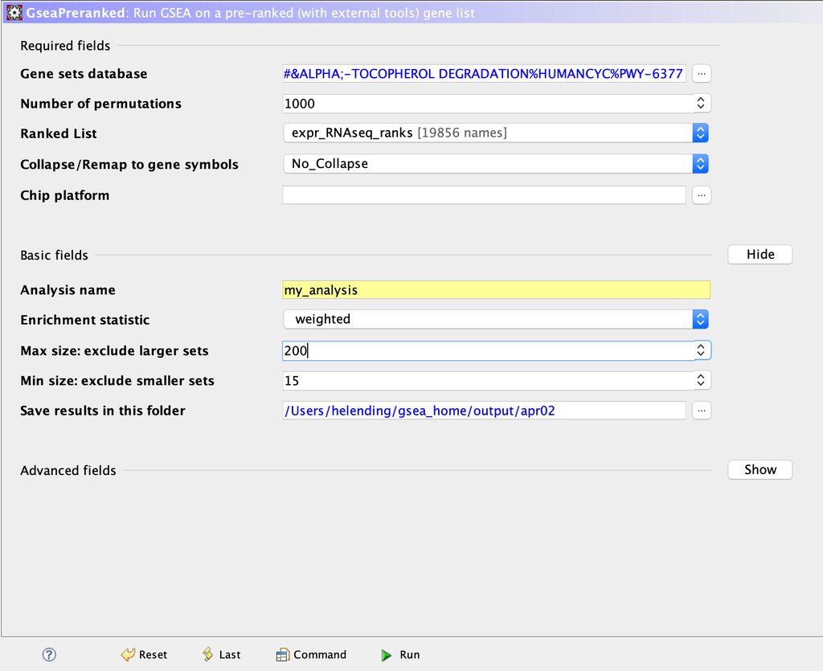

## 4. Summarize enrichment results

- For the “POS” group,
  - Humoral immune response is the top term
  - P-val = 0,
  - 9 genes in its leading edge
  - The top gene associated with this geneset is IGKV2D-28.

Down-regulated_top_terms

[output not shown]

Down-regulated_top_terms

| NAME | SIZE | ES | NES | NOM.p.val | FDR.q.val | FWER.p.val | RANK.AT.MAX | LEADING.EDGE |
| --- | --- | --- | --- | --- | --- | --- | --- | --- |
| TGF_BETA_RECEPTOR%IOB%TGF_BETA_RECEPTOR | 185 | -0.2044902 | NA | NA | 1 | 0 | 1836 | tags=15%, list=9%, signal=16% |
| HALLMARK_ADIPOGENESIS%MSIGDB_C2%HALLMARK_ADIPOGENESIS | 193 | -0.3041408 | NA | NA | 1 | 0 | 2169 | tags=23%, list=11%, signal=26% |
| HALLMARK_OXIDATIVE_PHOSPHORYLATION%MSIGDB_C2%HALLMARK_OXIDATIVE_PHOSPHORYLATION | 197 | -0.6852279 | NA | NA | 1 | 0 | 2021 | tags=39%, list=10%, signal=43% |
| HALLMARK_P53_PATHWAY%MSIGDB_C2%HALLMARK_P53_PATHWAY | 195 | -0.2911640 | NA | NA | 1 | 0 | 2716 | tags=24%, list=14%, signal=28% |
| TRANSPORT TO THE GOLGI AND SUBSEQUENT MODIFICATION%REACTOME DATABASE ID RELEASE 71%948021 | 155 | -0.1743973 | NA | NA | 1 | 0 | 3435 | tags=24%, list=17%, signal=29% |
| MITOTIC ANAPHASE%REACTOME DATABASE ID RELEASE 71%68882 | 173 | -0.4131416 | NA | NA | 1 | 0 | 3058 | tags=32%, list=15%, signal=37% |

## 5. Compare to the results from thresholded analysis

# Part 2: Visualize Gene set Enrichment Analysis

## 1. Create an enrichment map

- The following visualization is conducted using Cytoscape (Lopes et al. 2010)
- The parameters I used when creating the enrichment map: FDR was set to 0.01, others are kept as default.
- Basic information: there are 456 nodes and 5087 edges in the resulting map.
- Here is a screenshot that gives information about the creation of the enrichment map.

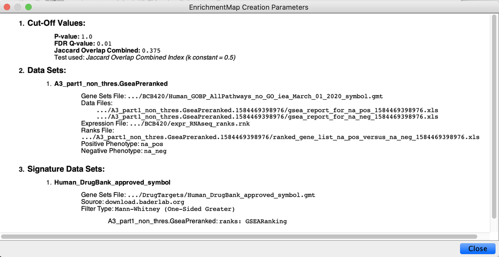

## 2. Annotate the enrichment map

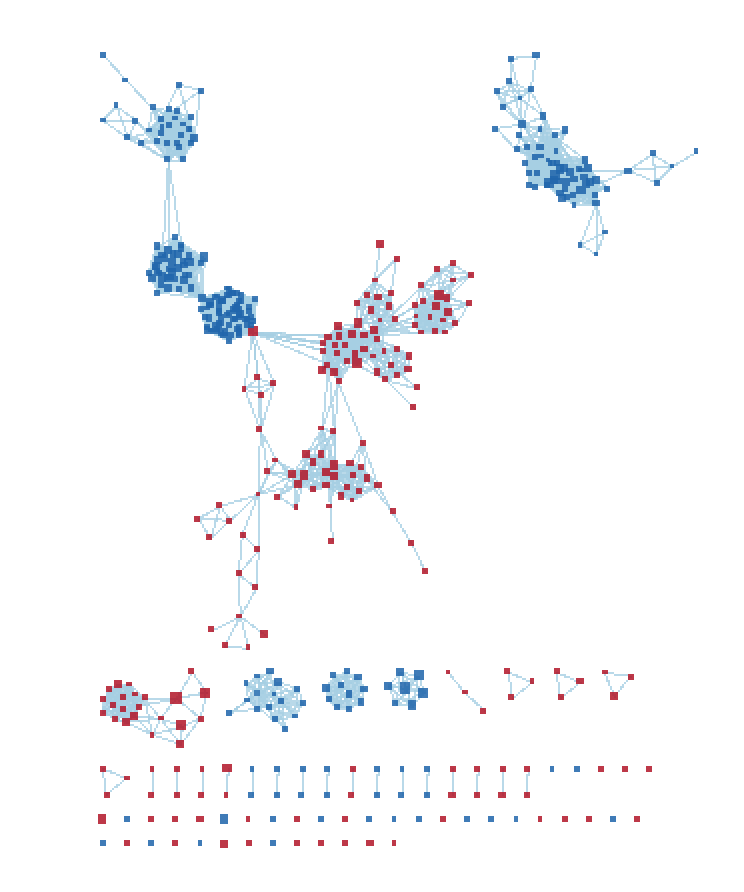

## 3. Manually edit the network

- I made sure that there is no overlap between the labels and the nodes. I also oragnized them to make the interactions clearer. The legend is obtained from Bader lab’s website.
- I did not screenshot the network since it is the same as the resulting graph that also contains the two drugs I picked. The screenshot can be found in the section: " Post analysis - Drug Bank".

## 4. Collapse to a theme network

- Generally, the major themes I found after collapsing the annotated network: immune responses, cell proliferation, tageting, and signaling.There seems to be no novel pathways.
- Here is an overview of the collapsed graph.

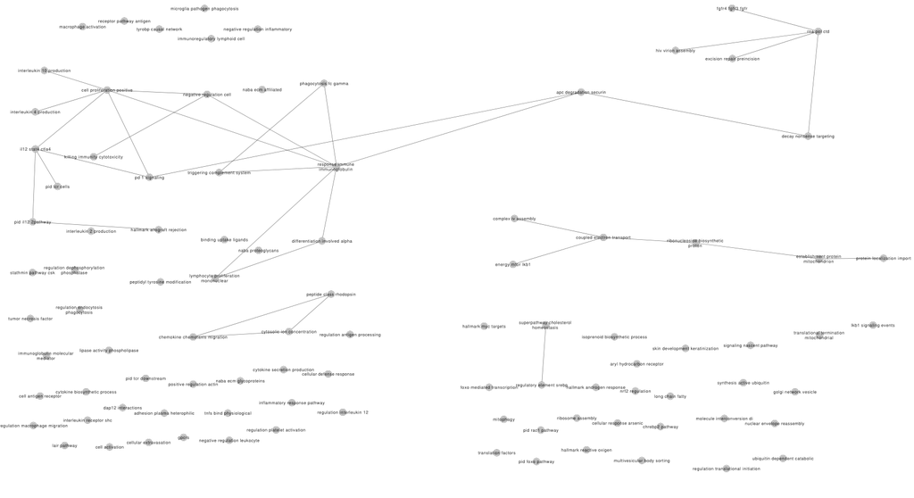

## 5. Interpretation of the annotated network

# 6. Post analysis - Drug Bank

The reason why I choose to do the post analysis with drugs is because the paper mentioned about finding a target for a drug. The drug is Pacritinib. However, this drug is not annotated, and thus not stored in the Bader Lab file. Therefore, I chose the top drug (Abciximab) (Law et al. 2014) from Bader lab approved drugs file. The paper also mentioned that they use Gemcitabine to treat breast cancer if the disease does not expand further.

- Parameters: Mann Whiteney(One-sided greater): since I do not care whether it targets the up-regulated or down-regulated genes.
- The resulting graph shows that there are no connection for Gemcitabine with any pathways, and a lot of up-regulated genes are targeted by Abciximab. The terms that are targeted are mostly the up-regulated genes, such as “response immune immunoglobin”, to reduce the elevated level of the antibody. It also reduces the level of other cell metabolic terms that are in the same pathway as the “response immune immunoglobin” (discussed in the section above). The main function of this drug is to reduce antibodies, and other over-produced molecules, but not elevating the weak terms (the down-regulated genes).
- The only thing not expected is that Gemcitabine does not target the term “cell proliferation positive” which is what the main object of Gemcitabine. Gemcitabine is a drug that kills the fast-growing cells. Therefore, it is not expected to see that this drug does nothing in this disease pathway.
- It might be hard to see the Gemcitabine, it is right beside Abciximab,.

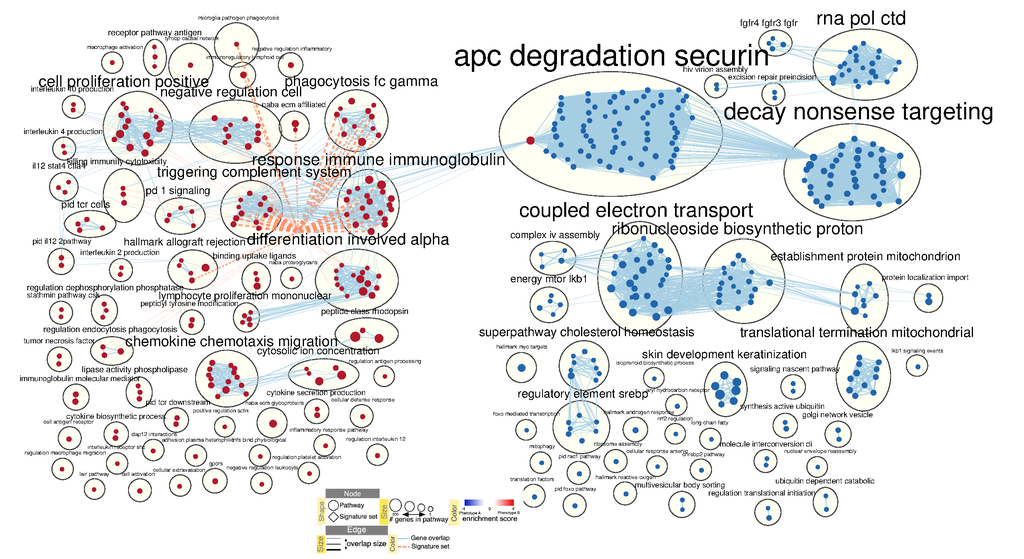

[figure not shown]

# References

Annick Moisan, Nathalie Villa-Vialaneix, Ignacio Gonzales. n.d. “Practical Statistical Analysis of Rna-Seq Data - edgeR - Tomato Data.”

Efron, Brad, and R. Tibshirani. 2019. *GSA: Gene Set Analysis*. https://CRAN.R-project.org/package=GSA.

Goh, Jian Yuan, Min Feng, Wenyu Wang, Gokce Oguz, Siti Maryam JM Yatim, Puay Leng Lee, Yi Bao, et al. 2017. “Chromosome 1q21.3 Amplification Is a Trackable Biomarker and Actionable Target for Breast Cancer Recurrence.” *Nature Medicine* 23 (11). Nature Publishing Group: 1319.

Gu, Zuguang, Roland Eils, and Matthias Schlesner. 2016. “Complex Heatmaps Reveal Patterns and Correlations in Multidimensional Genomic Data.” *Bioinformatics*.

Gu, Zuguang, Lei Gu, Roland Eils, Matthias Schlesner, and Benedikt Brors. 2014. “Circlize Implements and Enhances Circular Visualization in R.” *Bioinformatics* 30 (19): 2811–2.

Kolberg, Liis, and Uku Raudvere. 2019. *Gprofiler2: Interface to the ’G:Profiler’ Toolset*. https://CRAN.R-project.org/package=gprofiler2.

Law, Vivian, Craig Knox, Yannick Djoumbou, Tim Jewison, An Chi Guo, Yifeng Liu, Adam Maciejewski, et al. 2014. “DrugBank 4.0: Shedding New Light on Drug Metabolism.” *Nucleic Acids Research* 42 (D1). Oxford University Press: D1091–D1097.

Lopes, Christian T, Max Franz, Farzana Kazi, Sylva L Donaldson, Quaid Morris, and Gary D Bader. 2010. “Cytoscape Web: An Interactive Web-Based Network Browser.” *Bioinformatics* 26 (18). Oxford University Press: 2347–8.

Qiu, Xiaoyan, Xiaohui Zhu, Liang Zhang, Yuntao Mao, Jian Zhang, Peng Hao, Guohui Li, et al. 2003. “Human Epithelial Cancers Secrete Immunoglobulin G with Unidentified Specificity to Promote Growth and Survival of Tumor Cells.” *Cancer Research* 63 (19). AACR: 6488–95.

Rainer, Johannes. 2017. *EnsDb.Hsapiens.v75: Ensembl Based Annotation Package*.

Ritchie, Matthew E, Belinda Phipson, Di Wu, Yifang Hu, Charity W Law, Wei Shi, and Gordon K Smyth. 2015. “limma Powers Differential Expression Analyses for RNA-Sequencing and Microarray Studies.” *Nucleic Acids Research* 43 (7): e47. https://doi.org/10.1093/nar/gkv007.

Robinson, M D, D J McCarthy, and G K Smyth. 2010. “EdgeR: A Bioconductor Package for Differential Expression Analysis of Digital Gene Expression Data.” *Bioinformatics* 26 (1): 139–40. https://doi.org/10.1093/bioinformatics/btp616.

Temple Lang, Duncan. 2020. *RCurl: General Network (Http/Ftp/...) Client Interface for R*. https://CRAN.R-project.org/package=RCurl.

Vasiliou, Vasilis, and Daniel W Nebert. 2005. “Analysis and Update of the Human Aldehyde Dehydrogenase (Aldh) Gene Family.” *Human Genomics* 2 (2). BioMed Central: 138.

Vassalli, Giuseppe. 2019. “Aldehyde Dehydrogenases: Not Just Markers, but Functional Regulators of Stem Cells.” *Stem Cells International* 2019. Hindawi.

Xie, Yihui. 2020. *Knitr: A General-Purpose Package for Dynamic Report Generation in R*. https://yihui.org/knitr/.

Zhu, Hao. 2019. *KableExtra: Construct Complex Table with ’Kable’ and Pipe Syntax*. https://CRAN.R-project.org/package=kableExtra.